# Math Journal

D. Zack Garza

University of Georgia  
dzackgarza@gmail.com

Last updated: 2021-04-10%

# 1 2021-04-09

## 1.1 18:12

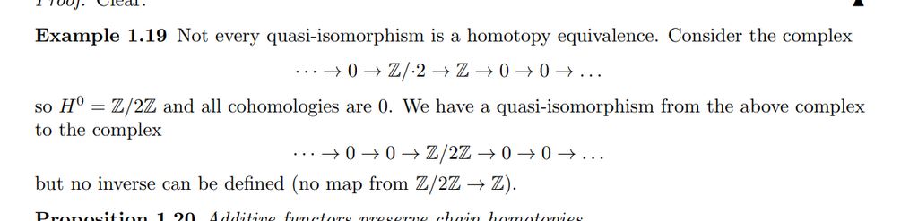

# 2 2021-04-08

## 2.1 18:11

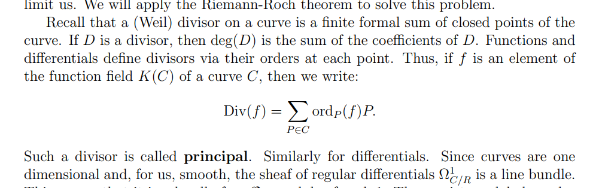

## 2.2 23:24

- [Reading recommendations](https://math.mit.edu/~notzeb/rec.html)

# 3 2021-04-04

## 3.1 16:53

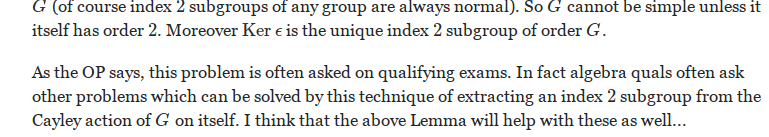

image_2021-04-04-16-53-57

# 4 2021-04-03

## 4.1 16:28

> The connections between FGLs and homotopy are key. Read Quillen’s paper, J.F. Adams’ blue book, Ravenel, etc. Ravenel has some slides on Quillen’s work (good entry pt). If you really want to go in depth, I enjoyed learning from Hazewinkel’s book “Formal Groups and Applications.”

## 4.2 16:30

### 4.2.1 Setting Goals

- Don’t set goals to be outcome-dependent. Set input goals! E.g. “Write a book that I’m proud of and I like.”
- Don’t set goals that depend on factors outside of your control – hitting some metric, getting a specific award, etc.
- Check in with your emotional state. It’s not always healthy to push through not feeling like doing something. This can be useful if it’s a matter of discipline, i.e. if pushing through is actually serving you well. But it can also serve you poorly in the long run by exacerbating poor mental state or leading to burnout.
- It’s okay to take a break. Check in to ask yourself if it’s coming from a place of self-care or instead procrastination.
- Choose to be satisfied! The story you tell yourself after the fact does not change the reality of the past. Does it serve you well to say “I didn’t do enough?” It’s okay to choose to be satisfied.

### 4.2.2 Studying

- Have a mental model is the key priority, then go to rote memorization only when absolutely necessary. Remember because you understand the subject!
- Use active recall for the *learning* process – actively test yourself **as** you’re reading.
- See book: “Make It Stick”
- The evidence is that popular techniques have low utility: rereading, highlighting, summarizing, taking notes.
- Summarizing and taking notes: low utility in general. This has some marginal utility if you’re particularly skilled or trained in summarizing effectively. So not very effective, but do it if it brings you joy!
- Active recall and practice testing: high utility! Not very time-intensive, doesn’t require special skills/training.
- Do practice testing **during each study session**. Studies show 10-15% improvement. Try to ask yourself inference questions.
- Studies show that those doing retrieval practice actually predict the smallest improvements and achieve the highest improvements. Very counterintuitive, trust the process!
- Reading once and practice testing can be more effective than rereading 4 times, *and* takes less time.
- Make first draft of notes with the book closed, no references.
- Spaced repetition: also works on a micro scale! E.g. within a single study session.
  - Recalling within a single session leads to almost a 30% increase in retention. Multiple successive recalls leads to no incremental gain, but multiple *spaced* recalls boosts by an additional 50%. Note that the last two are the same amount of work – letting yourself forget slightly forces retrieval.
- Practice a little bit each day over a long period of time.
- Extremely important: scope your subject. Know the broad outline of the course inside and out. Can scope based on actual exams.
- Start from topics you *don’t* know as well. E.g. work backwards though lecture notes.
- Try interleaved practice: don’t necessarily need to master a topic before moving on, realizing that you’ll be reviewing it several times again before it’s needed.
  - Getting through a large number of topics can be more useful than getting through a single topic in detail.
- Idea for tracking system: put course outline by topics into a spreadsheet, then record dates of review next to each topic. Color code cells based on quality of recall.
- Revision needs to be a fluid process, not worth timetabling down to each section due to different time requirements for each. Pick what makes your brain work the hardest.

## 4.3 19:04

### 4.3.1 Spectral Sequences

> [Link to PDF](https://www2.math.upenn.edu/~yeya/spectral_sequence.pdf)
- Snake Lemma

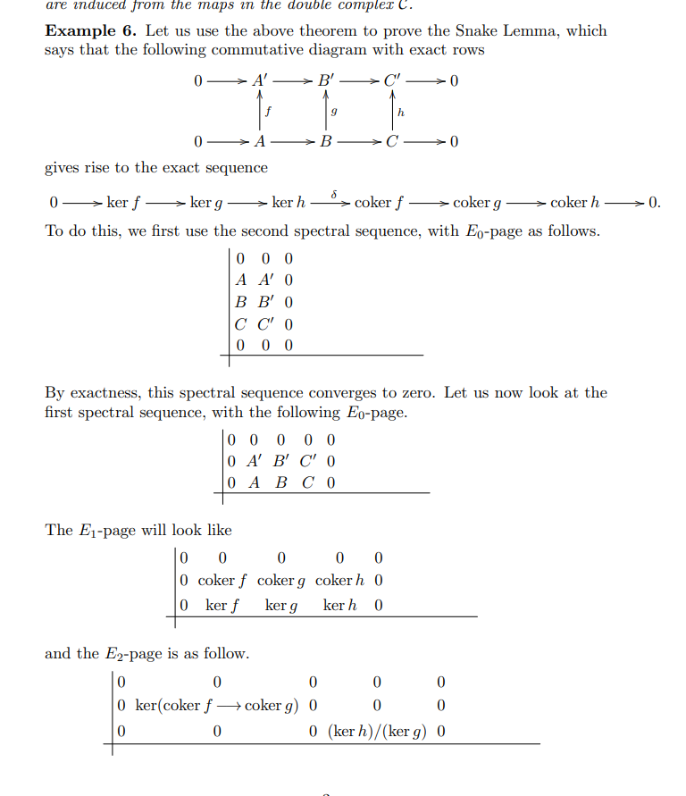

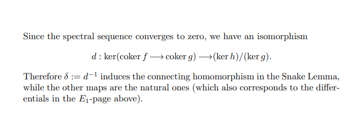

- Rational cohomology of $K(Z, n)$

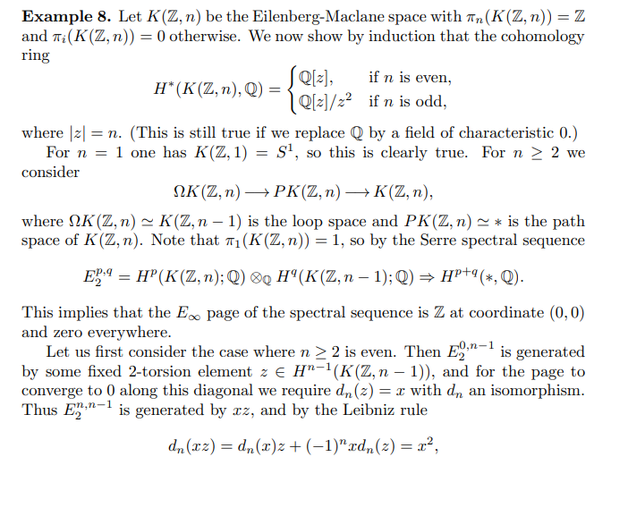

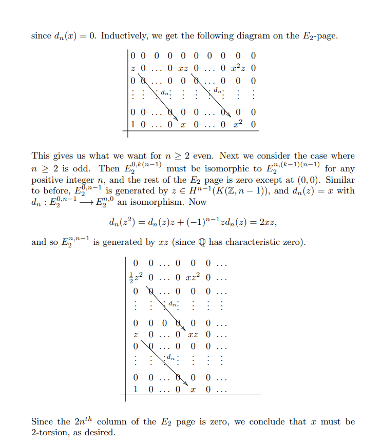

- Cohomology ring of ${\mathbb{CP}}^n$

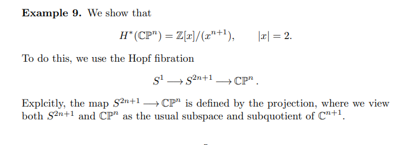

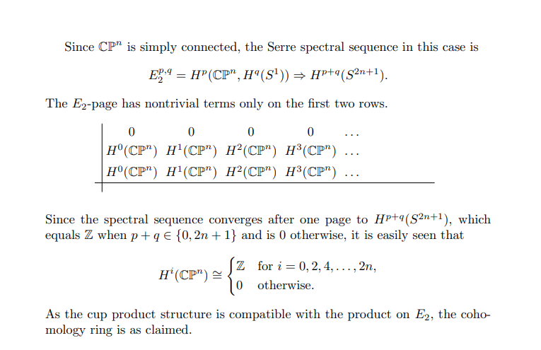

- The Lifting Problem

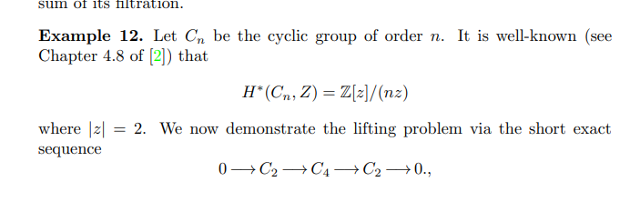

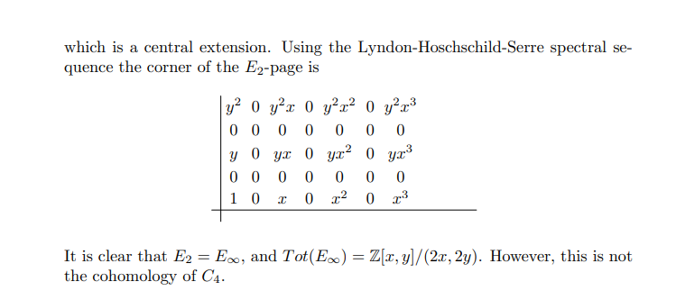

- Homotopy groups of spheres

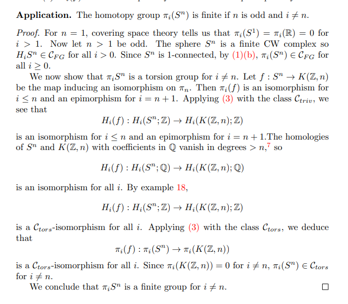

# 5 2021-04-02

## 5.1 22:38

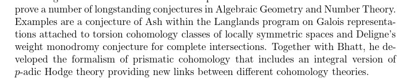

image_2021-04-02-22-38-21

# 6 2021-03-28

## 6.1 23:18

What is the **Weight-Monodromy Conjecture**?

# 7 2021-03-26

## 7.1 20:00

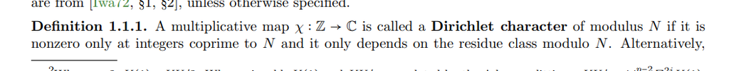

image_2021-03-26-20-00-58

- A Dirichlet character is equivalent to a group homomorphism
  $$\begin{align*}
  \chi:(\mathbb{Z} / N)^{\times} \rightarrow \mathbb{C}^{\times}
  .\end{align*}$$
- Definition of a Dirichlet $L{\hbox{-}}$function:
  $$\begin{align*}
  L(s ; \chi):=\sum_{n=1}^{\infty} \frac{\chi(n)}{n^{s}}
  =
  =\prod_{p}\left(1-\chi(p) p^{-s}\right)^{-1}
  .\end{align*}$$

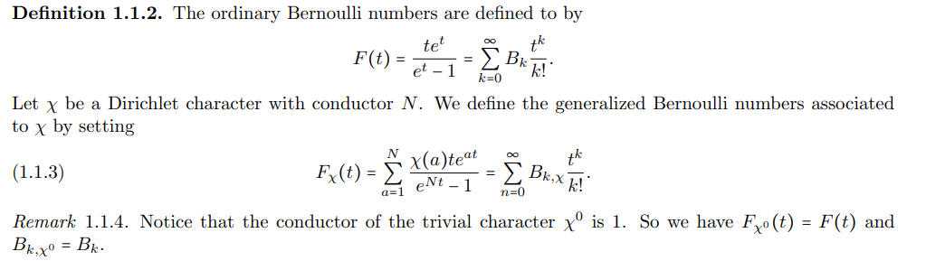

image_2021-03-26-20-03-27

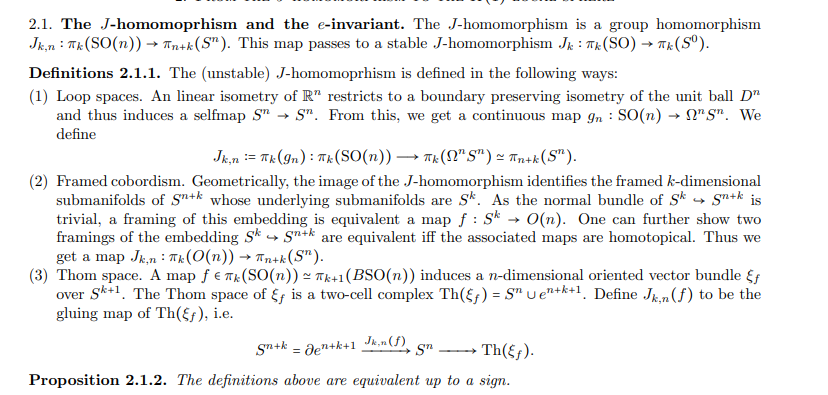

The J homomorphism

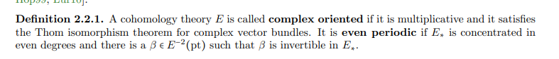

image_2021-03-26-20-06-00

- Uniformizer $\pi$: generator of a maximal ideal.

# 8 2021-03-25

## 8.1 00:08

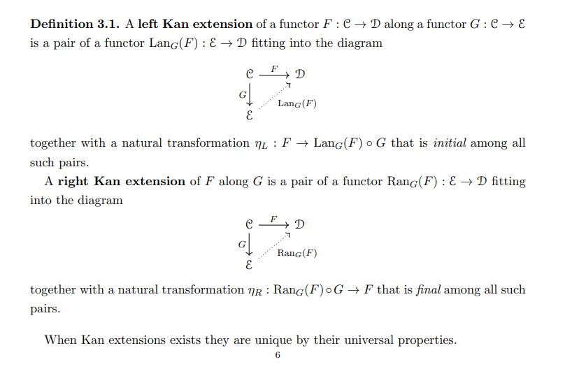

Kan extensions

## 8.2 00:09

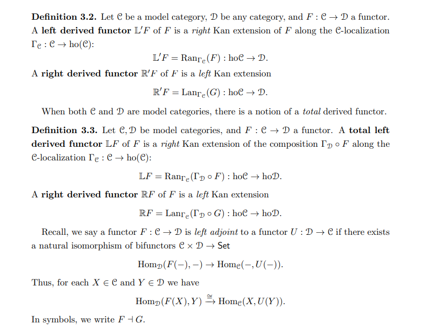

Derived functors

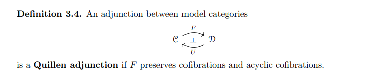

Quillen adjunctions

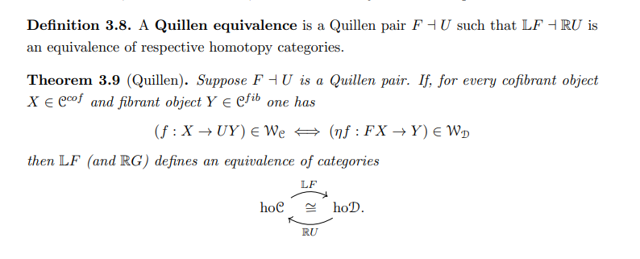

Quillen Equivalence

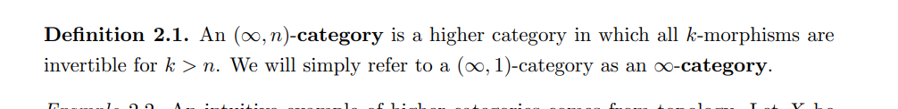

Infty n category

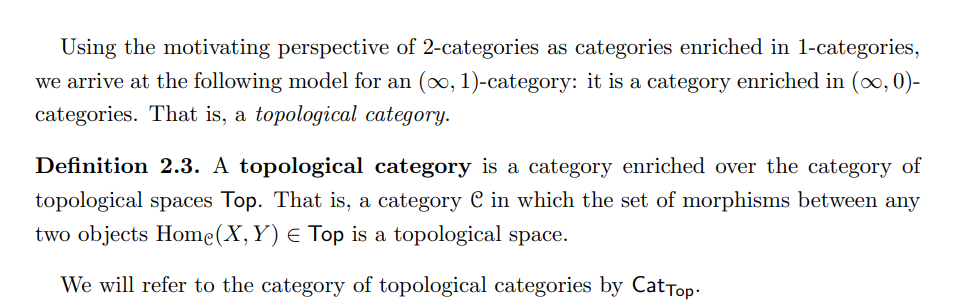

Topological categories

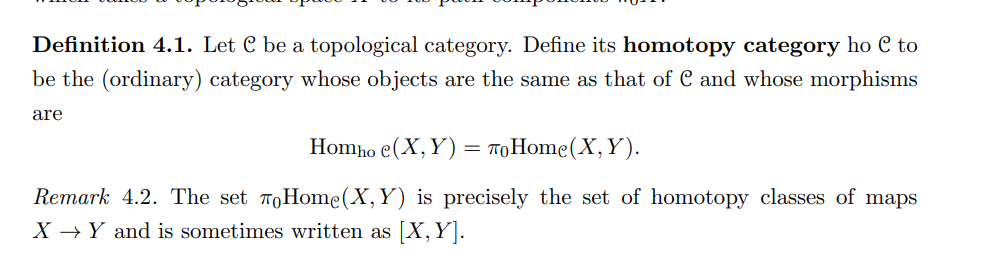

Homotopy category

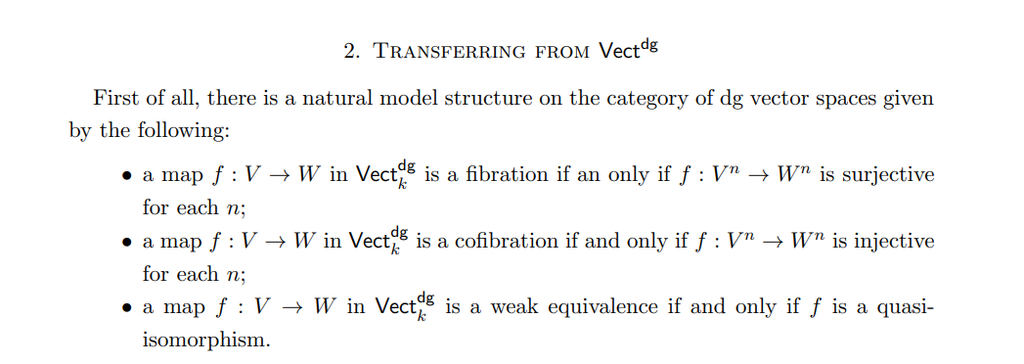

Model structure on dg vector spaces

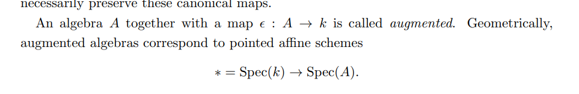

Augmented algebras are pointed schemes

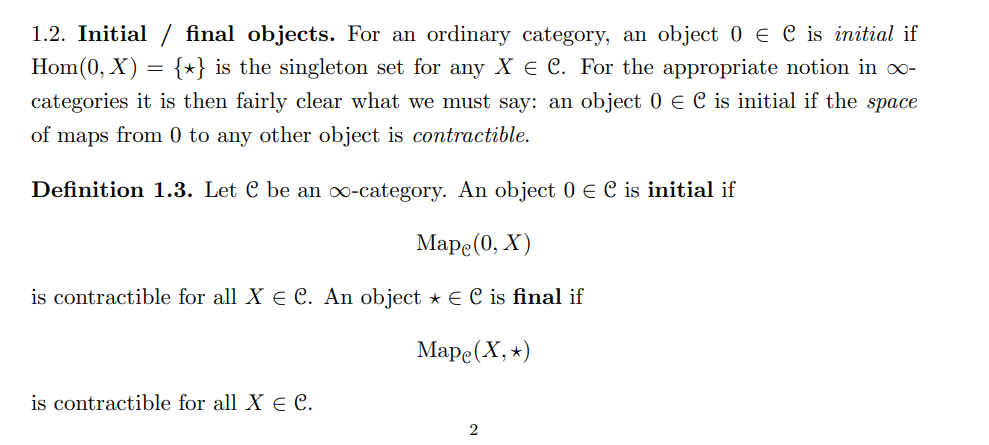

Initial and final objects in infty-categories

# 9 2021-03-24

## 9.1 00:11

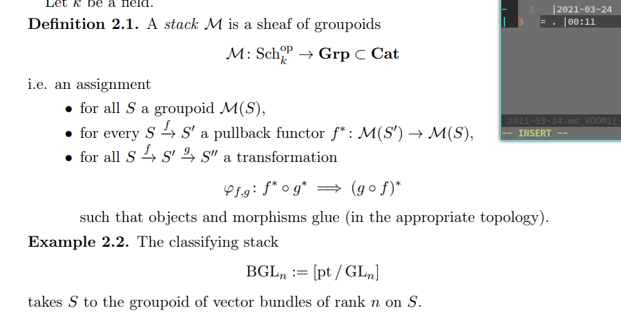

Definition of Stack

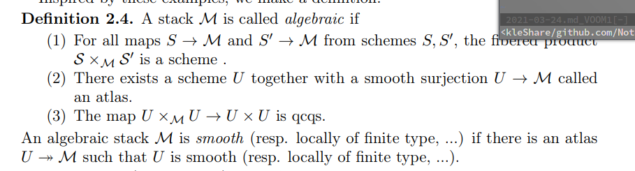

Algebraic and smooth stacks

- What are Quot schemes?

# 10 2021-03-17

## 10.1 17:00

- What is a local field?
- What is a global field?
  - Why are these generally more difficult than local fields?
- What is a field that is not local or global?
- What is a fibration of varieties?
- What is a del Pezzo surface?
- What is the Jacobian of a curve?
- What is the genus of a curve?
- What is a torsor?
- What is a complete intersection?
- What are some examples of $p{\hbox{-}}$adic fields?
- What is a Severi-Brauer variety?
- What is Hensel’s Lemma?
- What is quadratic reciprocity?
  - Conics over global fields fail to have rational points at an even number of places?
- What is a ramified/unramified extension?
- Interpretation of Weil conjectures: has lots of points over big enough extensions?
- What is the Hasse Principle?
- What are adelic points?
  - Product of $K_v$ points!
- What is the Brauer group?
- What is a central simple algebra?
- What are the main theorems of class field theory?
- Why is the following SES important:
  $$\begin{align*}
  0 \to \mathop{\mathrm{Br}}k \to \oplus_v \mathop{\mathrm{Br}}k_v \to {\mathbb{Q}}/{\mathbb{Z}}\to 0
  .\end{align*}$$
- What is a model of a variety?
- What is a special fiber?

# 11 2021-01-21

## 11.1 13:37

- Local coefficient systems

## 11.2 14:27

- Separated
- Locally quasi-finite
- Quasi-affine morphisms

## 11.3 16:13

- Smooth
- Geometrically connected

# 12 2021-01-20

## 12.1 16:52

- Geometric point
- Hyperelliptic curve
- Jacobian
- Mordell-Weil Theorem

## 12.2 20:00

- Exact and closed forms.

# 13 2021-01-19

## 13.1 16:29

- Canonical bundle!
- ${\mathcal{O}}(1)$
- $\omega^{\otimes k}$.

# 14 2021-01-05

## 14.1 00:01

- Chow groups
- Picard group

# 15 2021-01-03

## 15.1 18:05

- Vojta’s conjecture: Gives good height estimates, can be used to prove something is finite.
- Northcott’s theorem: Used in arithmetic dynamics since bounded height and bounded degree implies finite.